# Bank Authentication - R Supervised Learning

Project: Bank Authentication

Player: Jin Wang

This is an R warmup exercise. The aim of this is try to find an automated and trustable way to check the banknote.

Data were extracted from images that were taken from genuine and forged banknote-like specimens. For digitization, an industrial camera usually used for print inspection was used. The final images have 400x 400 pixels. Due to the object lens and distance to the investigated object gray-scale pictures with a resolution of about 660 dpi were gained. Wavelet Transform tool were used to extract features from images.

Details of the Wavelet transform can be found: https://en.wikipedia.org/wiki/Wavelet_transform

Attribute Information:

1. variance of Wavelet Transformed image (continuous)
2. skewness of Wavelet Transformed image (continuous)
3. curtosis of Wavelet Transformed image (continuous)
4. entropy of image (continuous)
5. class (integer)

[figure not shown]

```r
# Import the libraries

library(psych)
library(dplyr)
library(ggplot2)
library(readr)
library(caret)
```

```r
# read and check the data structures
df <- read_csv("data_banknote_authentication.csv")
# Check the structure
glimpse(df)
```

```
Observations: 1,372
Variables: 5
$ Image.Var  <dbl> 3.62160, 4.54590, 3.86600, 3.45660, 0.32924, 4.36840, 3.59120, 2.09220, 3.20320, 1.53560, 1....
$ Image.Skew <dbl> 8.66610, 8.16740, -2.63830, 9.52280, -4.45520, 9.67180, 3.01290, -6.81000, 5.75880, 9.17720,...
$ Image.Curt <dbl> -2.80730, -2.45860, 1.92420, -4.01120, 4.57180, -3.96060, 0.72888, 8.46360, -0.75345, -2.271...
$ Entropy    <dbl> -0.44699, -1.46210, 0.10645, -3.59440, -0.98880, -3.16250, 0.56421, -0.60216, -0.61251, -0.7...
$ class      <int> 0, 0, 0, 0, 0, 0, 0, 0, 0, 0, 0, 0, 0, 0, 0, 0, 0, 0, 0, 0, 0, 0, 0, 0, 0, 0, 0, 0, 0, 0, 0,...
```

```r
# Check mean, sd, summar info
describe(df)
```

```
           vars    n  mean   sd median trimmed  mad    min   max range  skew kurtosis   se
Image.Var     1 1372  0.43 2.84   0.50    0.50 3.41  -7.04  6.82 13.87 -0.15    -0.76 0.08
Image.Skew    2 1372  1.92 5.87   2.32    2.21 6.49 -13.77 12.95 26.72 -0.39    -0.44 0.16
Image.Curt    3 1372  1.40 4.31   0.62    0.93 3.48  -5.29 17.93 23.21  1.09     1.26 0.12
Entropy       4 1372 -1.19 2.10  -0.59   -0.95 1.71  -8.55  2.45 11.00 -1.02     0.49 0.06
class         5 1372  0.44 0.50   0.00    0.43 0.00   0.00  1.00  1.00  0.22    -1.95 0.01
```

##### We have the image variants, skewness,kurtosis and entropy and then we have class indicate if banknote is authentic.

##### Now check the top 6 rows.

```r
library(DT)
datatable(head(df))
```

|  | Image.Var | Image.Skew | Image.Curt | Entropy | class |
| --- | --- | --- | --- | --- | --- |
| 1 | 3.6216 | 8.6661 | -2.8073 | -0.44699 | 0 |
| 2 | 4.5459 | 8.1674 | -2.4586 | -1.4621 | 0 |
| 3 | 3.866 | -2.6383 | 1.9242 | 0.10645 | 0 |
| 4 | 3.4566 | 9.5228 | -4.0112 | -3.5944 | 0 |
| 5 | 0.32924 | -4.4552 | 4.5718 | -0.9888 | 0 |
| 6 | 4.3684 | 9.6718 | -3.9606 | -3.1625 | 0 |

##### Explore the correlation and distribution

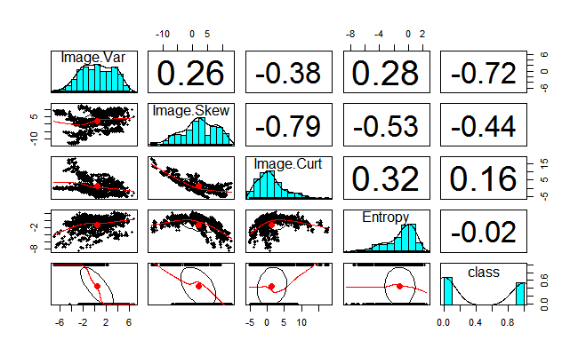

```r
pairs.panels(df)
```

##### Generally, if it is quantiative value with less nosie, standardization is needed.

##### I didn’t scale or normalized the data, because they are at the same order of magnitude and they have small ranges.

##### It may not be a big deal if not normalize the data. I still can do it when training the data.

```r
ggplotly(ggplot(data = df, aes(x = Image.Var, y = Image.Skew, col = class)) + geom_point()+ theme_bw())
```

[interactive chart not shown]

```r
ggplotly(ggplot(data = df, aes(x = Image.Curt, y = Entropy, col = class)) + geom_point() + theme_bw() )
```

[interactive chart not shown]

```r
ggplotly(ggplot(data = df, aes(x = Entropy, y = Image.Skew, col = class)) + geom_jitter() + theme_bw())
```

[interactive chart not shown]

```r
df$class <- as.factor(df$class)
```

##### Split the data to 70/30

```r
inTrain <- createDataPartition( y = df$class, p = .7, list = FALSE)
train <- df[inTrain,]
test <- df[-inTrain,]
```

##### Check if contain NULL data.

##### If contain NULL data, prepare to impute them with KNN

[output not shown]

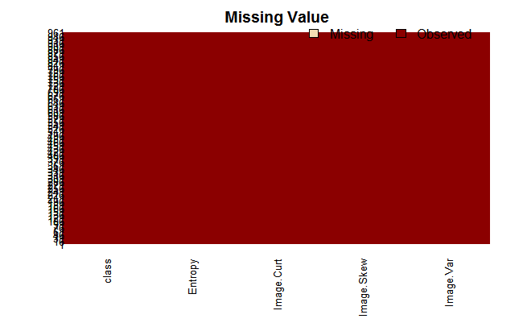

```r
library(Amelia)
missmap(train, main = "Missing Value")
```

##### Now create Train control - 10 fold cross validation.

```r
fitControl <- trainControl(method = "repeatedcv", repeats = 2, number = 10  )
```

##### Train the model and preProcess scale the data.

```r
set.seed(1234)
## Try the random forest model
model.rf <- train(data = train, class ~., method = "ranger", trControl = fitControl , preProcess = c("center", "scale"))
## Try the generalized linear model with penalized maximum likelihood
model.net <- train(data = train, class ~., method = "glmnet", trControl = fitControl ,  preProcess = c("center", "scale"), tuneGrid = expand.grid(alpha = 0:1, lambda = seq(0.0001,1,length = 20)) )
```

```r
print(model.rf)
```

```
Random Forest

961 samples
  4 predictor
  2 classes: '0', '1'

Pre-processing: centered (4), scaled (4)
Resampling: Cross-Validated (10 fold, repeated 2 times)
Summary of sample sizes: 866, 864, 865, 865, 864, 864, ...
Resampling results across tuning parameters:

  mtry  Accuracy   Kappa
  2     0.9891050  0.9778824
  3     0.9885842  0.9768167
  4     0.9859798  0.9715095

Accuracy was used to select the optimal model using  the largest value.
The final value used for the model was mtry = 2.
```

### check the generalized linear model

```r
print(model.net)
```

```
glmnet

961 samples
  4 predictor
  2 classes: '0', '1'

Pre-processing: centered (4), scaled (4)
Resampling: Cross-Validated (10 fold, repeated 2 times)
Summary of sample sizes: 866, 865, 865, 865, 865, 865, ...
Resampling results across tuning parameters:

  alpha  lambda      Accuracy   Kappa
  0      0.00010000  0.9594113  0.9178511
  0      0.05272632  0.9557870  0.9101314
  0      0.10535263  0.9391304  0.8755612
```

[output cut: 40 more lines]

Predict on the test dataset by using random forest

```r
test.rf <- predict(model.rf, test)
```

Using confusion Matrix to check the accuracy and recall

```r
confusionMatrix(data = test.rf, reference = test$class)
```

```
Confusion Matrix and Statistics

          Reference
Prediction   0   1
         0 225   4
         1   3 179

               Accuracy : 0.983
                 95% CI : (0.9652, 0.9931)
    No Information Rate : 0.5547
    P-Value [Acc > NIR] : <2e-16

                  Kappa : 0.9655
 Mcnemar's Test P-Value : 1

            Sensitivity : 0.9868
            Specificity : 0.9781
         Pos Pred Value : 0.9825
         Neg Pred Value : 0.9835
             Prevalence : 0.5547
         Detection Rate : 0.5474
   Detection Prevalence : 0.5572
      Balanced Accuracy : 0.9825

       'Positive' Class : 0
```

```r
confusionMatrix(test.net, reference = test$class)
```

```
Confusion Matrix and Statistics

          Reference
Prediction   0   1
         0 227   2
         1   1 181

               Accuracy : 0.9927
                 95% CI : (0.9788, 0.9985)
    No Information Rate : 0.5547
    P-Value [Acc > NIR] : <2e-16

                  Kappa : 0.9852
 Mcnemar's Test P-Value : 1

            Sensitivity : 0.9956
            Specificity : 0.9891
         Pos Pred Value : 0.9913
         Neg Pred Value : 0.9945
             Prevalence : 0.5547
         Detection Rate : 0.5523
   Detection Prevalence : 0.5572
      Balanced Accuracy : 0.9923

       'Positive' Class : 0
```

##### Compare two model choose the high accuracy linear regular model.

##### The accuracy is 99%.